# DATA 606 Final Project

Priya Shaji

2019-05-08

## Adolescent Pregnancy Analysis

### Introduction

**What is Adolescent Prenancy?**

Teenage pregnancy, also known as adolescent pregnancy, is pregnancy in a female under the age of 20.

Adolescent pregnancies are a global problem that occurs in high, middle, and low income countries. Around the world, adolescent pregnancies are more likely to occur in marginalized communities, commonly driven by poverty and lack of education and employment opportunities

The global adolescent birth rate has declined from 65 births per 1000 women in 1990 to 47 births per 1000 women in 2015. Despite this overall progress, because the global population of adolescents continues to grow, projections indicate the number of adolescent pregnancies will increase globally by 2030, with the greatest proportional increases in West and Central Africa and Eastern and Southern Africa.

Additionally, regional differences reveal unequal progress: adolescent birth rates range from a high of 115 births per 1000 women in West Africa to 64 births per 1000 women in Latin America and the Caribbean to 45 births per 1000 women in South-Eastern Asia, to a low of 7 births per 1000 women in Eastern Asia. There are also up to three times more adolescent pregnancies in rural and indigenous populations than in urban populations.

By doing analysis on adolescent pregnancy rates, I want to research on the following point:

1. Which countries have the most significant increasing/decreasing adolescent fertility rates.
2. Determine potential reasons for what in particular makes countries with decreasing or consistent fertility rates different from countries with higher or increasing fertility rates?

And, find out solutions on how we can help empower adolescents/women or give them access to the right tools so they won’t be caught in a cycle of continuous pregnancy.

### Data

1. Now, since we know our goals of this analysis and are aware of the dataset we have, we will load all the required libraires

```r
library(dplyr)
library(tidyr)
library(ggplot2)
library(ggfortify)
```

2. Load the `gender world indicator` dataset which was downloaded from [World Bank](http://wdi.worldbank.org/table/WV.5%20https://data.worldbank.org/topic/gender)

```r
# load data
gendered_world_indicators <- read.csv("https://raw.githubusercontent.com/PriyaShaji/Adolescent-Pregnancy-Final-Projects/master/Gender_World%20_Indicators.csv", header=TRUE, check.names = FALSE)
```

### Exploratory data analysis

Let’s explore the dataset

3. The first step for an exploratory dataset is to transform the dataset.

Perform data transformations using functions given by tidyr and dplyr packages.

4. We’ll gather all the year in the data and make it as a new column name values for column “year”

```r
tidy_gendered_world_indicators <- gather(gendered_world_indicators, "year", "n", 5:60)
```

5. Rename the column name “Country Name” as “Country”

and “Indicator Name” as “Indicator”

6. The new name of our clean and tidy dataset is tidy_gendered_world_indicators

```r
colnames(tidy_gendered_world_indicators)[colnames(tidy_gendered_world_indicators) == "Country Name"] <- "Country"
colnames(tidy_gendered_world_indicators)[colnames(tidy_gendered_world_indicators) == "Indicator Name"] <- "Indicator"
tidy_gendered_world_indicators <- select(tidy_gendered_world_indicators, one_of("Country", "Indicator","year", "n"))
tidy_gendered_world_indicators <- na.omit(tidy_gendered_world_indicators)
indicators <- unique(tidy_gendered_world_indicators$Indicator)
```

#### Philippines

According to US National Library research, Philippines is one of the few countries in the world that have an increase in adolecent fertility rates.

7. Filter data for Philippines by using filter() function of dplyr package.
8. Using ggplot(), plot the fertility rates vs years for Philippines

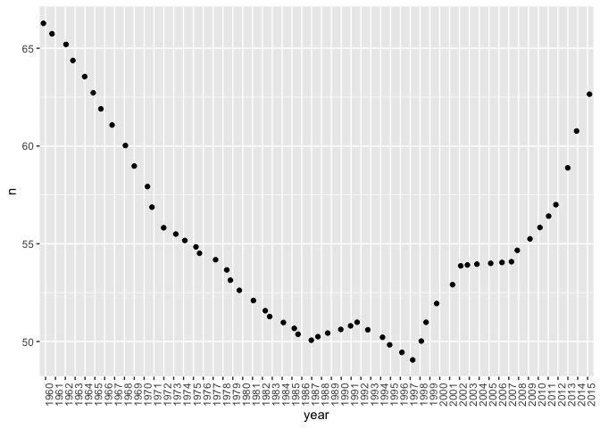

```r
Philippines <- tidy_gendered_world_indicators %>%
  filter(Country == "Philippines")
fertility_phi <- Philippines %>%
  filter(Indicator == indicators[8])
PHI_fertility <- ggplot(fertility_phi, aes(year, n))
PHI_fertility + geom_jitter() + theme(axis.text.x = element_text(angle = 90, hjust = 1))
```

Here we see, the fertility rate for Philippines was highest during 1960 and that rate has been decreasing constantly till 1997. Since then the rates has been increasing constantly till 2015.

#### United States of America

9. Filter data for United States by using filter() function of dplyr package.
10. Using ggplot(), plot the fertility rates vs years for United States

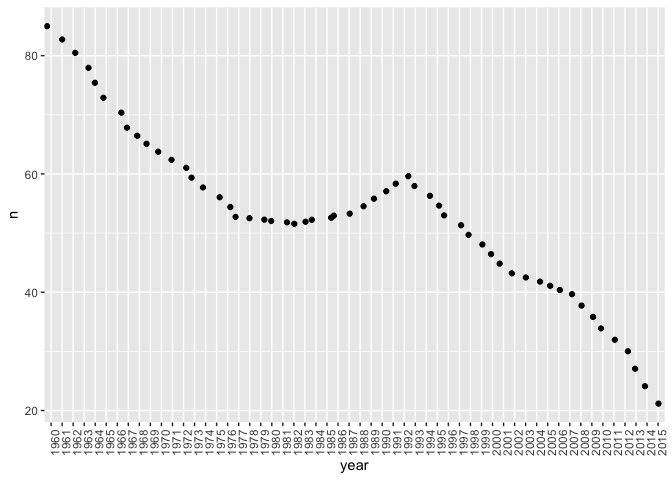

```r
United_States <- tidy_gendered_world_indicators %>%
  filter(Country == "United States")
fertility_usa <- United_States %>%
  filter(Indicator == indicators[8])
indicators <- unique(United_States$Indicator)
USA_fertility <- ggplot(fertility_usa, aes(year, n))
USA_fertility + geom_jitter() + theme(axis.text.x = element_text(angle = 90, hjust = 1))
```

The United States of America’s adolescent birth rate is generally decreasing, despite a slight uptick during the late 80’s to early ’90s.

#### Switzerland

According to US National Library research, Switzerland is one of the few countries in the world that have a decrease in adolecent fertility rates.

11. Filter data for Switzerland by using filter() function of dplyr package.
12. Using ggplot(), plot the fertility rates vs years for Switzerland

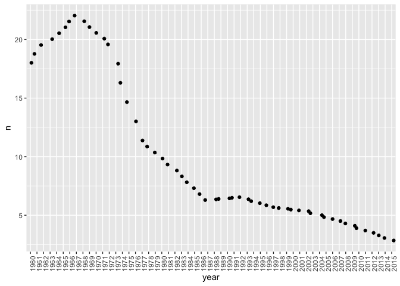

```r
Switzerland <- tidy_gendered_world_indicators %>%
  filter(Country == "Switzerland")
fertility_Swi <- Switzerland %>%
  filter(Indicator == indicators[8])
SWI_fertility <- ggplot(fertility_Swi, aes(year, n))
SWI_fertility + geom_jitter() + theme(axis.text.x = element_text(angle = 90, hjust = 1))
```

Switzerland adolescent birth rate has a constant decreasing trend from 1967 onwards.

So, here as we see, all three countries have varying rates of adolescent fertility. Therefore

#### Global Perspective Approach

First, let’s take a globalized approach to understanding adolescent birth rates.

The World Bank provides us with adolescent birth rate data going back to the 1960’s, but also provides data for many other “Indicators”. These Indicators often vary from country to country, but all countries also have these Indicators: Survival to age 65, female (% of cohort) and Survival to age 65, male (% of cohort). Let’s use it to see a bigger picture about how mens and womens health care and how they affect young teenagers having kids. Is there any correlation?

13. Create a new variable and plotting a density plot of pregnency rates of all the countries given in our tidy dataset.

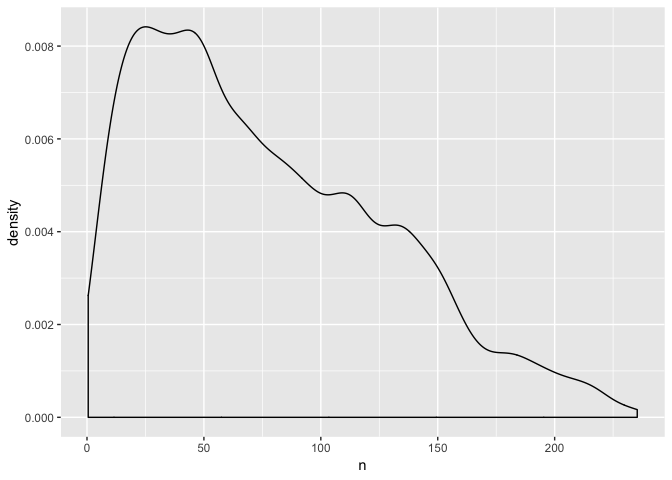

```r
pregnancy <- tidy_gendered_world_indicators %>%
  filter(Indicator == indicators[8])
a <- ggplot(pregnancy, aes(n))
a + geom_density()
```

14. If we perform multiple linear regression on our Indicators Survival to age 65, female (% of cohort) and Survival to age 65, male (% of cohort) against Adolescent Pregnancy rates per 1000 teenagers from 15-19, we get the following
15. Perform regression analysis for the gendered world indicators we considered above

```r
fertility_survival <- summary(lm(fertility$n~ survival_65_female$n + survival_65_male$n))
fertility_survival
```

```
##
## Call:
## lm(formula = fertility$n ~ survival_65_female$n + survival_65_male$n)
##
## Residuals:
##      Min       1Q   Median       3Q      Max
## -143.012  -18.619   -2.936   18.273  143.989
##
## Coefficients:
##                       Estimate Std. Error t value Pr(>|t|)
## (Intercept)          236.65239    1.12107  211.10   <2e-16 ***
## survival_65_female$n   0.90526    0.06529   13.86   <2e-16 ***
## survival_65_male$n    -3.13280    0.05915  -52.96   <2e-16 ***
## ---
## Signif. codes:  0 '***' 0.001 '**' 0.01 '*' 0.05 '.' 0.1 ' ' 1
##
## Residual standard error: 32.31 on 13437 degrees of freedom
## Multiple R-squared:  0.6169, Adjusted R-squared:  0.6168
## F-statistic: 1.082e+04 on 2 and 13437 DF,  p-value: < 2.2e-16
```

Note that the residuals are relatively normal and we have a large population size.

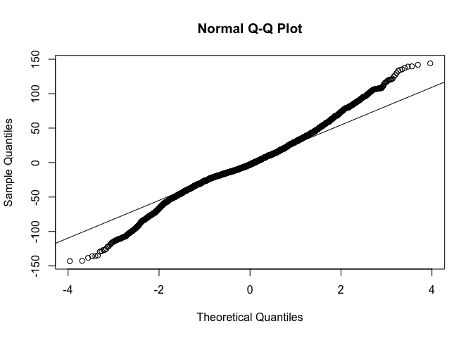

```r
qqnorm(fertility_survival$residuals)
qqline(fertility_survival$residuals)
```

Next, let’s use these same Indicators and run multiple linear regression for our three countries in question: Philippines, United States, and Switzerland.

##### Philippines

16. Density plot for Philippines fertility rate

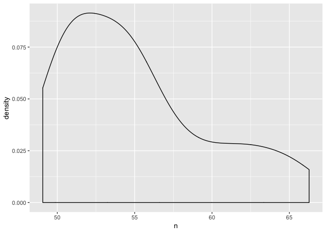

```r
a <- ggplot(fertility_phi, aes(n))
a + geom_density()
```

17. Perform regression analysis for the gendered world indicators we considered above

```r
fertility_survival_phi <- summary(lm(fertility_p$n~male_65_percent_phi$n + female_65_percent_phi$n))
fertility_survival_phi
```

```
##
## Call:
## lm(formula = fertility_p$n ~ male_65_percent_phi$n + female_65_percent_phi$n)
##
## Residuals:
##    Min     1Q Median     3Q    Max
## -6.519 -2.903 -0.166  2.140  8.649
##
## Coefficients:
##                         Estimate Std. Error t value Pr(>|t|)
## (Intercept)             -132.002     52.366  -2.521 0.014754 *
## male_65_percent_phi$n      8.780      2.145   4.093 0.000146 ***
## female_65_percent_phi$n   -4.544      1.020  -4.454 4.38e-05 ***
## ---
## Signif. codes:  0 '***' 0.001 '**' 0.01 '*' 0.05 '.' 0.1 ' ' 1
##
## Residual standard error: 3.637 on 53 degrees of freedom
## Multiple R-squared:  0.4336, Adjusted R-squared:  0.4122
## F-statistic: 20.29 on 2 and 53 DF,  p-value: 2.87e-07
```

$$\widehat{\mathrm{births \; per \; 1,000 \; women \; ages \; 15-19}} = \beta_0 + \beta_1(Percent \; survival \; to \; 64, \; male) + \beta_2(Percent \; survival \; to \; 64, female)$$
$$\widehat{\mathrm{births \; per \; 1,000 \; women \; ages \; 15-19}} = -132.002 + 8.780(Percent \; survival \; to \; 64, \; male) - 4.544 (Percent \; survival \; to \; 64, female)$$

Notice how much of an increase male survival impacts adolescent pregnancy. An article, published in August points us to a potential reason why.

> “The Philippines is struggling to manage its soaring teen pregnancy rates. The United Nations Population Fund (UNFPA) has found that teen pregnancies in the Philippines increased by 65% from 2000-2010. An estimated 24 babies are born to teen mothers every hour. Now, advocates and health workers are identifying a new trend: Teenage girls are not just getting pregnant, but doing so with much older men. They say it’s the need for financial security that drives girls into such relationships.” https://www.globalcitizen.org/en/content/teen-pregnancy-older-men-philippines/

This isn’t a foreign concept to for many filipinos. Research says there are many filipino men who travel back to their homeland with promises of money or material goods for a night or ongoing relationship with an underage girl. Underage for American standards, that is. The age of consent back home is only 12 years old.

On a more positive note, there is hope. Every percent of elder females decreases births per 1000 by 4. As mentioned before, perhaps an increase in care for women leads to less teenage births. This could be because of influences from matornly figures such as mothers, aunts, and grandmothers that are around and can nurture young women in the family. Family is incredibly important in the Philippines. If women can be role models or nurture their young daughters/sons to be careful, then we could potentially positively impact birth rates in the Philippines.

To view the relationship between the Indicators, we can observe trends in the graph below.

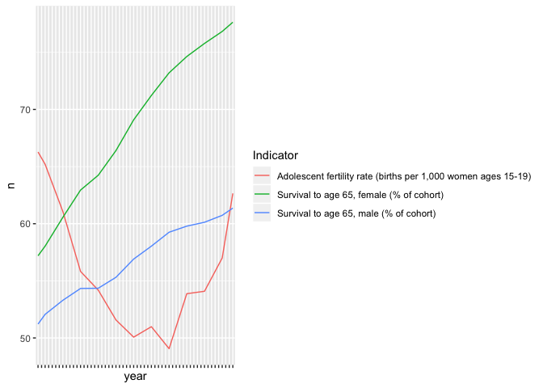

```r
f <- ggplot(data=phi_health, aes(year, n, group=Indicator))
f + geom_line(aes(color=Indicator)) + theme(axis.text.x = element_blank() )
```

##### United States

The United States follows a very normal distribution, as shown by the linear relationship shown earlier. In contrast to the World density plot, we have a normal distribution.

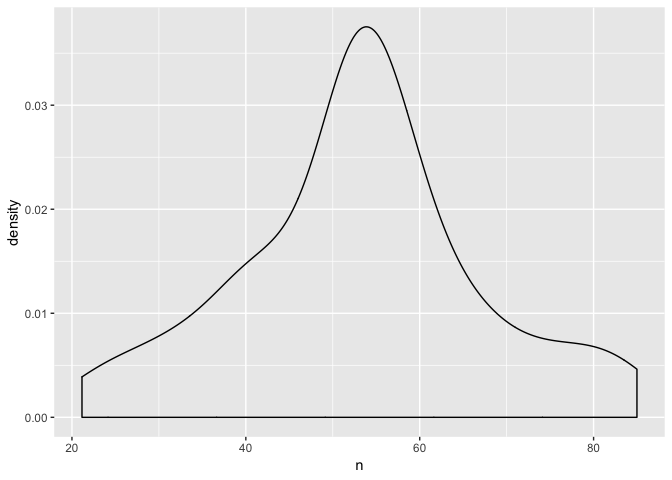

```r
a <- ggplot(fertility_usa, aes(n))
a + geom_density()
```

18. Perform regression analysis for the gendered world indicators we considered above

```r
fertility_survival_usa <- summary(lm(fertility_u$n~male_65_percent_usa$n + female_65_percent_usa$n))
fertility_survival_usa
```

```
##
## Call:
## lm(formula = fertility_u$n ~ male_65_percent_usa$n + female_65_percent_usa$n)
##
## Residuals:
##      Min       1Q   Median       3Q      Max
## -15.1155  -3.9812  -0.4512   3.3197  13.1536
##
## Coefficients:
##                         Estimate Std. Error t value Pr(>|t|)
## (Intercept)              543.980     92.907   5.855 3.08e-07 ***
## male_65_percent_usa$n      1.814      1.055   1.719 0.091404 .
## female_65_percent_usa$n   -7.410      2.006  -3.694 0.000523 ***
## ---
## Signif. codes:  0 '***' 0.001 '**' 0.01 '*' 0.05 '.' 0.1 ' ' 1
##
## Residual standard error: 5.935 on 53 degrees of freedom
## Multiple R-squared:  0.8282, Adjusted R-squared:  0.8217
## F-statistic: 127.7 on 2 and 53 DF,  p-value: < 2.2e-16
```

Here, our R2 is .82 and the p-value is less than .05. Our equation is

$$\widehat{\mathrm{births \; per \; 1,000 \; women \; ages \; 15-19}} = \beta_0 + \beta_1(Percent \; survival \; to \; 64, \; male) + \beta_2(Percent \; survival \; to \; 64, female)$$

$$\widehat{\mathrm{births \; per \; 1,000 \; women \; ages \; 15-19}} = 543.980 + 1.814(Percent \; survival \; to \; 64, \; male) - 7.410 (Percent \; survival \; to \; 64, female)$$

Similar story as the Philippines is being shown here.

To view the relationship between the Indicators, we can observe trends in the graph below.

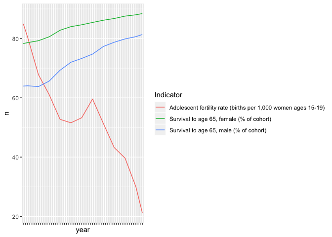

```r
f <- ggplot(data=usa_health, aes(year, n, group=Indicator))
f + geom_line(aes(color=Indicator)) + theme(axis.text.x = element_blank() )
```

Similar to Philippines,In USA, rate of fertility decreases as the survival rates of male and female increases.

##### Switzerland

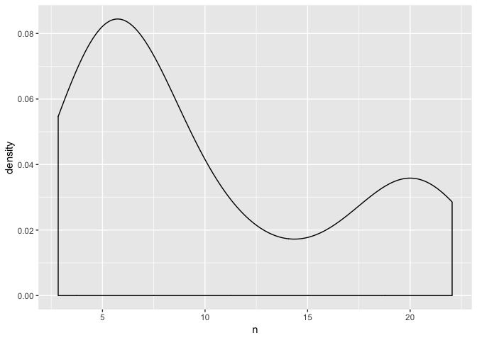

```r
a <- ggplot(fertility_Swi, aes(n))
a + geom_density()
```

19. Perform regression analysis for the gendered world indicators we considered above

```r
fertility_survival_Swi <- summary(lm(fertility_p$n~male_65_percent_Swi$n + female_65_percent_Swi$n))
fertility_survival_Swi
```

```
##
## Call:
## lm(formula = fertility_p$n ~ male_65_percent_Swi$n + female_65_percent_Swi$n)
##
## Residuals:
##     Min      1Q  Median      3Q     Max
## -3.8018 -0.9680  0.0979  0.7998  6.7864
##
## Coefficients:
##                         Estimate Std. Error t value Pr(>|t|)
## (Intercept)             348.2660    16.8120   20.71   <2e-16 ***
## male_65_percent_Swi$n     2.9366     0.2046   14.35   <2e-16 ***
## female_65_percent_Swi$n  -5.9310     0.3656  -16.22   <2e-16 ***
## ---
## Signif. codes:  0 '***' 0.001 '**' 0.01 '*' 0.05 '.' 0.1 ' ' 1
##
## Residual standard error: 1.806 on 53 degrees of freedom
## Multiple R-squared:  0.8604, Adjusted R-squared:  0.8551
## F-statistic: 163.3 on 2 and 53 DF,  p-value: < 2.2e-16
```

Here, R2 is .86 and the p-value is less than .05. This may show us that there are alternative factors that *aren’t* related to medial advances. We do however, see a similar trend with male and female survival rates – although there is much less of a gendered distinction. Our equation is

$$\widehat{\mathrm{births \; per \; 1,000 \; women \; ages \; 15-19}} = \beta_0 + \beta_1(Percent \; survival \; to \; 64, \; male) + \beta_2(Percent \; survival \; to \; 64, female)$$

$$\widehat{\mathrm{births \; per \; 1,000 \; women \; ages \; 15-19}} = 348.2660 + 2.9366(Percent \; survival \; to \; 64, \; male) - 5.9310 (Percent \; survival \; to \; 64, female)$$

To view the relationship between the Indicators, we can observe trends in the graph below.

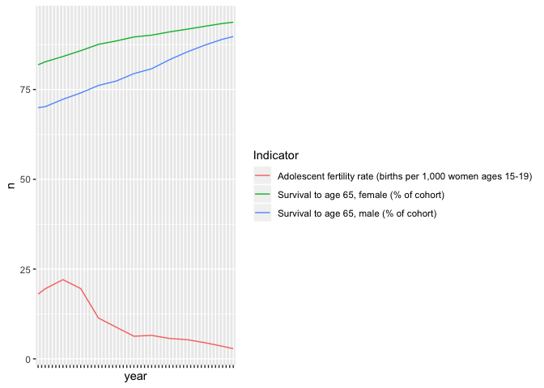

```r
f <- ggplot(data=Swi_health, aes(year, n, group=Indicator))
f + geom_line(aes(color=Indicator)) + theme(axis.text.x = element_blank() )
```

As we see clearly, the survival age of females upto or more than 65 years of age has an inverse impact on the adolescent fertility rates. As the survival rate of females increases, the adolescent fertility rate in Swizerland, decreases drastically.

#### Backward Elimination Approach

Since many of the indicators included (161 in total) don’t have complete information, we will only analyze the ones with more than 25 values. In general, factors were broken down into three main categories as data permits:

1. Employment
2. Education
3. Health

##### Philippines

The following factors are the values that we will be regressing against adolescent pregnancy rates for the Philippines.

```r
indicators_phi_backwards[1:7]
```

```
## [1] Labor force participation rate, female (% of female population ages 15+) (modeled ILO estimate)
## [2] Labor force participation rate, male (% of male population ages 15+) (modeled ILO estimate)
## [3] Labor force, female (% of total labor force)
## [4] Lifetime risk of maternal death (%)
## [5] Lifetime risk of maternal death (1 in: rate varies by country)
## [6] Maternal mortality ratio (modeled estimate, per 100,000 live births)
## [7] Prevalence of HIV, female (% ages 15-24)
## 161 Levels: Account at a financial institution, female (% age 15+) ...
```

**Employment**

20. Perform regression analysis for the gendered world indicators we considered above

```r
fertility_employment_phi <- summary(lm(fertility_phi_emp$n~ female_agriculture$n +
                             female_industry$n + female_services$n))
fertility_employment_phi
```

```
##
## Call:
## lm(formula = fertility_phi_emp$n ~ female_agriculture$n + female_industry$n +
##     female_services$n)
##
## Residuals:
##     Min      1Q  Median      3Q     Max
## -3.5812 -1.3614 -0.2444  0.6337  6.3384
##
## Coefficients:
##                      Estimate Std. Error t value Pr(>|t|)
## (Intercept)          1327.677    326.365   4.068 0.000223 ***
## female_agriculture$n  -12.723      3.224  -3.946 0.000322 ***
## female_industry$n     -13.546      3.487  -3.885 0.000385 ***
## female_services$n     -12.594      3.242  -3.885 0.000386 ***
## ---
## Signif. codes:  0 '***' 0.001 '**' 0.01 '*' 0.05 '.' 0.1 ' ' 1
##
## Residual standard error: 2.343 on 39 degrees of freedom
## Multiple R-squared:  0.4194, Adjusted R-squared:  0.3747
## F-statistic:  9.39 on 3 and 39 DF,  p-value: 8.45e-05
```

Even removing variables with the highest p-values, we do not have a very good model in terms of R2. I do not believe these employment metrics are a very useful to understand adolescent pregnancy in the Philippines. It is however better than looking at any one sector by itself, which yielded R2 values around .11.

**Education**

```r
fertility_education_phi <- summary(lm(fertility_phi_edu$n ~ female_primary_education_phi$n +
                             female_school_enrollment_phi$n + male_school_enrollment_phi$n))
fertility_education_phi
```

```
##
## Call:
## lm(formula = fertility_phi_edu$n ~ female_primary_education_phi$n +
##     female_school_enrollment_phi$n + male_school_enrollment_phi$n)
##
## Residuals:
##     Min      1Q  Median      3Q     Max
## -2.6510 -0.9744 -0.3875  1.0896  2.4366
##
## Coefficients:
##                                Estimate Std. Error t value Pr(>|t|)
## (Intercept)                    494.8829    90.0198   5.497 9.09e-06 ***
## female_primary_education_phi$n  -8.8507     1.6384  -5.402 1.17e-05 ***
## female_school_enrollment_phi$n   2.0464     0.3832   5.341 1.37e-05 ***
## male_school_enrollment_phi$n    -2.1453     0.4686  -4.578 0.000103 ***
## ---
## Signif. codes:  0 '***' 0.001 '**' 0.01 '*' 0.05 '.' 0.1 ' ' 1
##
## Residual standard error: 1.485 on 26 degrees of freedom
## Multiple R-squared:  0.6056, Adjusted R-squared:  0.5601
## F-statistic: 13.31 on 3 and 26 DF,  p-value: 1.86e-05
```

Since this model doesn’t have a very high R2, let’s run simple linear regression on the variable with the highest R2 and the most likely to affect teenage pregnancy – female school enrollment.

21. Perform regression analysis for the gendered world indicators we considered above

```r
fertility_education_phi <- summary(lm(fertility_phi_edu$n ~ female_school_enrollment_phi$n))
fertility_education_phi
```

```
##
## Call:
## lm(formula = fertility_phi_edu$n ~ female_school_enrollment_phi$n)
##
## Residuals:
##     Min      1Q  Median      3Q     Max
## -2.7072 -1.5055 -0.8293  2.0301  4.0793
##
## Coefficients:
##                                Estimate Std. Error t value Pr(>|t|)
## (Intercept)                     19.2076    15.0947   1.272   0.2137
## female_school_enrollment_phi$n   0.3046     0.1401   2.174   0.0383 *
## ---
## Signif. codes:  0 '***' 0.001 '**' 0.01 '*' 0.05 '.' 0.1 ' ' 1
##
## Residual standard error: 2.108 on 28 degrees of freedom
## Multiple R-squared:  0.1444, Adjusted R-squared:  0.1139
## F-statistic: 4.726 on 1 and 28 DF,  p-value: 0.03831
```

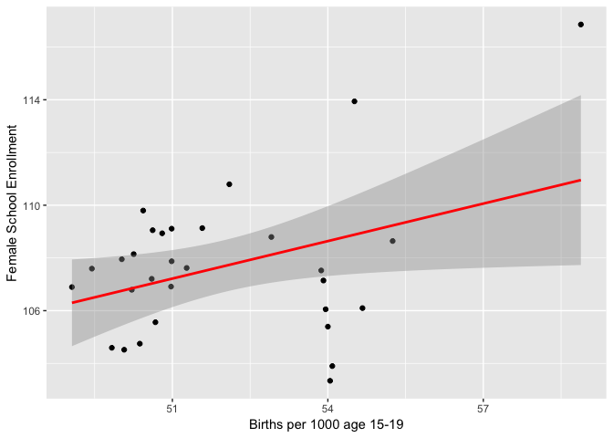

```r
ggplot(schoolphi, aes(x=n.x,y=n.y)) +
  geom_point() +
  stat_smooth(method = "lm", col = "red") +
  labs(x="Births per 1000 age 15-19",y="Female School Enrollment")
```

**Health**

22. Perform regression analysis for the gendered world indicators we considered above

```r
fertility_health_phi <- summary(lm(fertility_phi_health$n~ risk_maternal_death$n + maternal_mortality_ratio$n +
                             HIV_male_15to24$n))
fertility_health_phi
```

```
##
## Call:
## lm(formula = fertility_phi_health$n ~ risk_maternal_death$n +
##     maternal_mortality_ratio$n + HIV_male_15to24$n)
##
## Residuals:
##      Min       1Q   Median       3Q      Max
## -1.40026 -0.91039 -0.00734  0.45542  2.80484
##
## Coefficients:
##                             Estimate Std. Error t value Pr(>|t|)
## (Intercept)                 33.53837    4.30786   7.785 9.24e-08 ***
## risk_maternal_death$n      -43.52231    3.74912 -11.609 7.49e-11 ***
## maternal_mortality_ratio$n   0.27339    0.03856   7.090 4.12e-07 ***
## HIV_male_15to24$n           61.05476    8.59186   7.106 3.98e-07 ***
## ---
## Signif. codes:  0 '***' 0.001 '**' 0.01 '*' 0.05 '.' 0.1 ' ' 1
##
## Residual standard error: 1.027 on 22 degrees of freedom
## Multiple R-squared:  0.925,  Adjusted R-squared:  0.9148
## F-statistic:  90.5 on 3 and 22 DF,  p-value: 1.568e-12
```

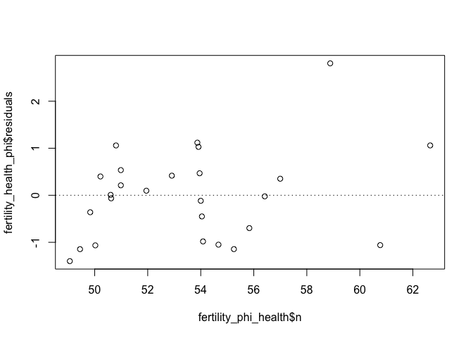

```r
plot(fertility_health_phi$residuals ~ fertility_phi_health$n)
abline(h = 0, lty = 3)
```

Health is by far our best model for understanding adolescent birth rates in the philippines, with an adjusted R squared of .91. I think the most interesting metric, is that the risk of maternal death. Let’s do simple regression on this indicator.

```r
fertility_health_phi <- summary(lm(fertility_phi_health$n ~ risk_maternal_death$n))
fertility_health_phi
```

```
##
## Call:
## lm(formula = fertility_phi_health$n ~ risk_maternal_death$n)
##
## Residuals:
##     Min      1Q  Median      3Q     Max
## -4.0460 -1.0595  0.0821  0.7907  4.5236
##
## Coefficients:
##                       Estimate Std. Error t value Pr(>|t|)
## (Intercept)             70.166      2.660  26.378  < 2e-16 ***
## risk_maternal_death$n  -34.190      5.407  -6.323 1.55e-06 ***
## ---
## Signif. codes:  0 '***' 0.001 '**' 0.01 '*' 0.05 '.' 0.1 ' ' 1
##
## Residual standard error: 2.199 on 24 degrees of freedom
## Multiple R-squared:  0.6249, Adjusted R-squared:  0.6093
## F-statistic: 39.99 on 1 and 24 DF,  p-value: 1.547e-06
```

For a single variable, this has one of the highest correlations. What does it tell us? That when the risk of death increases, births decrease. While its good that maternal death rates are decreasing during pregancies, it’s not good that teenage girls are having more pregancies. Perhaps teenage pregnancies were always high – but there are less birth related deaths now? Doesn’t really account for the sudden uptick after rates were decreasing in the 70s.

One thing to note, is that access to birth control isn’t very good in the Philippines. In this heavily orthodox country, it is deemed morally wrong and absinence is the only good option.

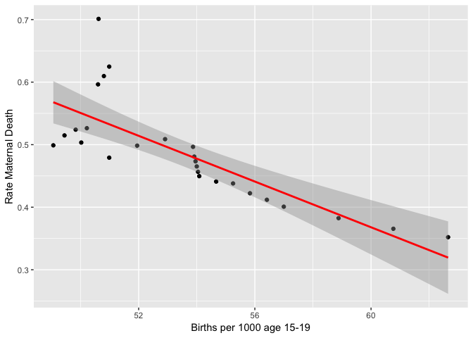

```r
ggplot(risk, aes(x=n.x,y=n.y)) +
  geom_point() +
  stat_smooth(method = "lm", col = "red") +
  labs(x="Births per 1000 age 15-19",y="Rate Maternal Death")
```

With an increase in maternal death rate, rate of adolescent fertility decreases.

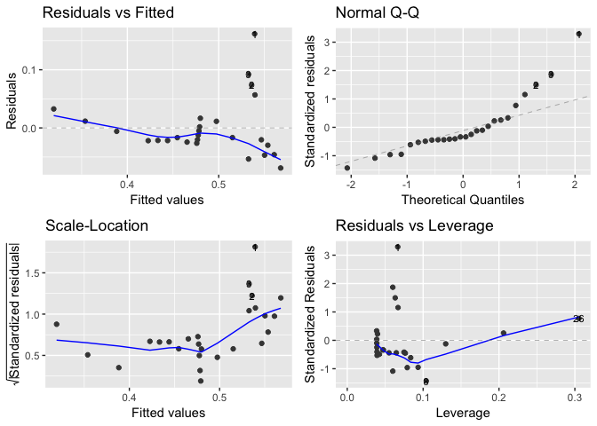

```r
autoplot(lm(n.y ~ n.x, data = risk), label.size = 3)
```

##### United States

The following are factors we are using for understanding adolescent pregnancy in the United States.

```r
USA_indicatiors_backwards
```

| Country | Indicator | N |
| --- | --- | --- |
| United States | Primary education, pupils (% female) | 31 |
| United States | School enrollment, primary (gross), gender parity index (GPI) | 31 |
| United States | School enrollment, primary, female (% gross) | 31 |
| United States | School enrollment, primary, male (% gross) | 31 |
| United States | School enrollment, secondary (gross), gender parity index (GPI) | 31 |
| United States | School enrollment, secondary, female (% gross) | 31 |
| United States | School enrollment, secondary, male (% gross) | 31 |
| United States | Secondary education, general pupils (% female) | 31 |
| United States | Secondary education, pupils (% female) | 31 |
| United States | Employment in industry, female (% of female employment) | 33 |

[output cut: 24 more lines]

**Employment**

23. Perform regression analysis for the gendered world indicators we considered above

```r
fertility_employment_usa <- summary(lm(fertility_usa_emp$n~ male_industry_usa$n +
                             male_services_usa$n + percent_female_family_contributes_usa$n +
                             male_self_emp_usa$n + male_agriculture_usa$n))
fertility_employment_usa
```

```
##
## Call:
## lm(formula = fertility_usa_emp$n ~ male_industry_usa$n + male_services_usa$n +
##     percent_female_family_contributes_usa$n + male_self_emp_usa$n +
##     male_agriculture_usa$n)
##
## Residuals:
##     Min      1Q  Median      3Q     Max
## -3.8889 -1.3204  0.0098  1.1188  3.2995
##
## Coefficients:
##                                           Estimate Std. Error t value
## (Intercept)                             -20747.372   7939.192  -2.613
## male_industry_usa$n                        208.263     79.437   2.622
## male_services_usa$n                        206.514     79.376   2.602
## percent_female_family_contributes_usa$n    -29.255      2.548 -11.480
## male_self_emp_usa$n                         10.434      1.026  10.166
## male_agriculture_usa$n                     205.526     79.241   2.594
##                                         Pr(>|t|)
## (Intercept)                               0.0145 *
## male_industry_usa$n                       0.0142 *
## male_services_usa$n                       0.0149 *
## percent_female_family_contributes_usa$n 6.79e-12 ***
## male_self_emp_usa$n                     9.97e-11 ***
## male_agriculture_usa$n                    0.0152 *
## ---
## Signif. codes:  0 '***' 0.001 '**' 0.01 '*' 0.05 '.' 0.1 ' ' 1
##
## Residual standard error: 1.922 on 27 degrees of freedom
## Multiple R-squared:  0.9725, Adjusted R-squared:  0.9674
## F-statistic: 190.6 on 5 and 27 DF,  p-value: < 2.2e-16
```

```r
fertility_employment_usa <- summary(lm(fertility_usa_emp$n ~ percent_female_workers_usa$n  ))
fertility_employment_usa
```

```
##
## Call:
## lm(formula = fertility_usa_emp$n ~ percent_female_workers_usa$n)
##
## Residuals:
##     Min      1Q  Median      3Q     Max
## -8.6354 -2.6870  0.3658  1.8562 12.1302
##
## Coefficients:
##                              Estimate Std. Error t value Pr(>|t|)
## (Intercept)                  1723.788    137.349   12.55 1.09e-13 ***
## percent_female_workers_usa$n  -17.905      1.465  -12.22 2.18e-13 ***
## ---
## Signif. codes:  0 '***' 0.001 '**' 0.01 '*' 0.05 '.' 0.1 ' ' 1
##
## Residual standard error: 4.481 on 31 degrees of freedom
## Multiple R-squared:  0.8281, Adjusted R-squared:  0.8225
## F-statistic: 149.3 on 1 and 31 DF,  p-value: 2.181e-13
```

As one can see from the graph below, the more females in the workplace, the less adolescent births within the United States of America.

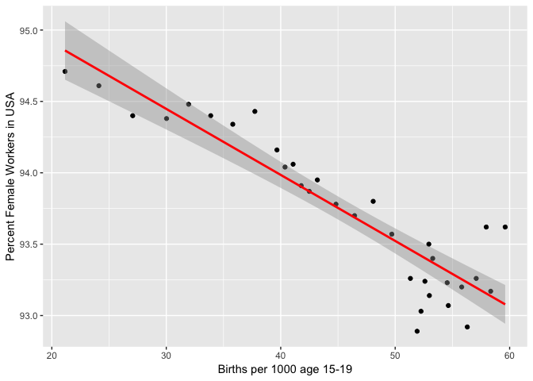

```r
ggplot(usawork, aes(x=n.x,y=n.y)) +
  geom_point() +
  stat_smooth(method = "lm", col = "red") +
  labs(x="Births per 1000 age 15-19",y="Percent Female Workers in USA")
```

Residuals appear nearly normal. As the percent of female workers increase in USA, adolescent fertility rate decreases.

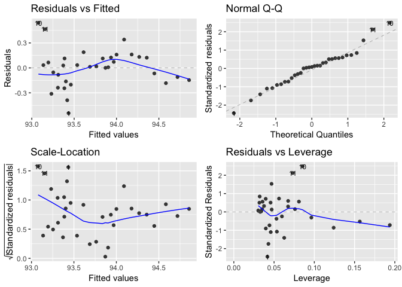

```r
autoplot(lm(n.y ~ n.x, data = usawork), label.size = 3)
```

**Education**

24. Perform regression analysis for the gendered world indicators we considered above

```r
fertility_education_phi <- summary(lm(fertility_usa_edu$n~ female_primary_edu_usa$n + gross_school_enrollment_usa$n +
                             female_primary_school_enrollment_usa$n + male_primary_school_enrollment_usa$n + gross_secondary_school_enrollment_usa$n +
                             male_secondary_school_enrollment_usa$n + female_secondary_education_usa$n +
                             gross_tertiary_enrollment_usa$n + female_tertiary_enrollment_usa$n + male_tertiary_enrollment_usa$n))
fertility_education_phi
```

```
##
## Call:
## lm(formula = fertility_usa_edu$n ~ female_primary_edu_usa$n +
##     gross_school_enrollment_usa$n + female_primary_school_enrollment_usa$n +
##     male_primary_school_enrollment_usa$n + gross_secondary_school_enrollment_usa$n +
##     male_secondary_school_enrollment_usa$n + female_secondary_education_usa$n +
##     gross_tertiary_enrollment_usa$n + female_tertiary_enrollment_usa$n +
##     male_tertiary_enrollment_usa$n)
##
## Residuals:
##      Min       1Q   Median       3Q      Max
## -2.86932 -0.92455  0.01899  0.67581  2.85783
##
## Coefficients:
##                                           Estimate Std. Error t value
## (Intercept)                             -6321.7290  1871.6004  -3.378
## female_primary_edu_usa$n                  -41.3183     5.2062  -7.936
## gross_school_enrollment_usa$n            8038.3195  1906.9879   4.215
## female_primary_school_enrollment_usa$n    -68.5551    18.5062  -3.704
## male_primary_school_enrollment_usa$n       70.7308    18.5655   3.810
## gross_secondary_school_enrollment_usa$n   352.4974    50.2126   7.020
## male_secondary_school_enrollment_usa$n     -1.9978     0.2214  -9.025
## female_secondary_education_usa$n          -14.4225     1.8847  -7.652
## gross_tertiary_enrollment_usa$n           462.1723    40.3458  11.455
## female_tertiary_enrollment_usa$n           -7.8488     0.6921 -11.341
## male_tertiary_enrollment_usa$n             11.1162     0.9594  11.586
##                                         Pr(>|t|)
## (Intercept)                             0.002991 **
## female_primary_edu_usa$n                1.32e-07 ***
## gross_school_enrollment_usa$n           0.000425 ***
## female_primary_school_enrollment_usa$n  0.001403 **
## male_primary_school_enrollment_usa$n    0.001097 **
## gross_secondary_school_enrollment_usa$n 8.25e-07 ***
## male_secondary_school_enrollment_usa$n  1.73e-08 ***
## female_secondary_education_usa$n        2.30e-07 ***
## gross_tertiary_enrollment_usa$n         3.08e-10 ***
## female_tertiary_enrollment_usa$n        3.67e-10 ***
## male_tertiary_enrollment_usa$n          2.52e-10 ***
## ---
## Signif. codes:  0 '***' 0.001 '**' 0.01 '*' 0.05 '.' 0.1 ' ' 1
##
## Residual standard error: 1.599 on 20 degrees of freedom
## Multiple R-squared:  0.9827, Adjusted R-squared:  0.9741
## F-statistic: 113.7 on 10 and 20 DF,  p-value: 2.245e-15
```

I think we can see that there is a big difference in how education and employment affects adolescent birth rates in USA. Nearly every value is statistically significant in our model.

```r
fertility_education_usa <- summary(lm(fertility_usa_edu$n ~   female_tertiary_enrollment_usa$n ))
fertility_education_usa
```

```
##
## Call:
## lm(formula = fertility_usa_edu$n ~ female_tertiary_enrollment_usa$n)
##
## Residuals:
##     Min      1Q  Median      3Q     Max
## -15.374  -2.824  -1.682   0.756  13.901
##
## Coefficients:
##                                  Estimate Std. Error t value Pr(>|t|)
## (Intercept)                      78.80793    5.42280  14.533 7.58e-15 ***
## female_tertiary_enrollment_usa$n -0.39050    0.06306  -6.193 9.40e-07 ***
## ---
## Signif. codes:  0 '***' 0.001 '**' 0.01 '*' 0.05 '.' 0.1 ' ' 1
##
## Residual standard error: 6.627 on 29 degrees of freedom
## Multiple R-squared:  0.5694, Adjusted R-squared:  0.5546
## F-statistic: 38.35 on 1 and 29 DF,  p-value: 9.402e-07
```

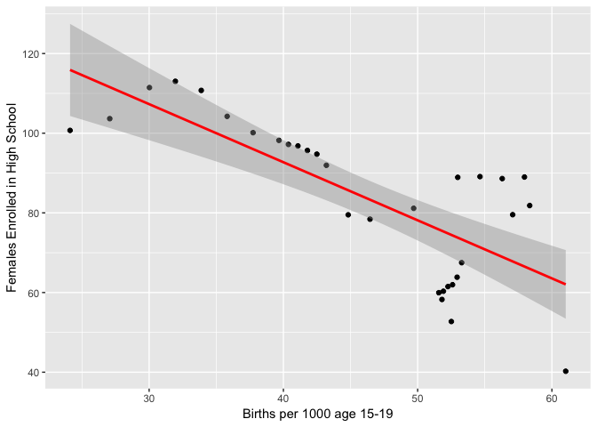

```r
ggplot(usaedu, aes(x=n.x,y=n.y)) +
  geom_point() +
  stat_smooth(method = "lm", col = "red") +
  labs(x="Births per 1000 age 15-19",y="Females Enrolled in High School")
```

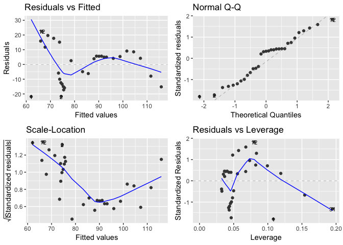

```r
autoplot(lm(n.y ~ n.x, data = usaedu), label.size = 3)
```

##### Switzerland

The following factors are the values that we will be regressing against adolescent pregnancy rates for Switzerland

```r
Switzerland_indicatiors_backwards
```

| Country | Indicator | N |
| --- | --- | --- |
| Switzerland | Contributing family workers, female (% of female employment) | 25 |
| Switzerland | Contributing family workers, male (% of male employment) | 25 |
| Switzerland | Employers, female (% of female employment) | 25 |
| Switzerland | Employers, male (% of male employment) | 25 |
| Switzerland | Employment to population ratio, 15+, female (%) (modeled ILO estimate) | 25 |
| Switzerland | Employment to population ratio, 15+, male (%) (modeled ILO estimate) | 25 |
| Switzerland | Employment to population ratio, ages 15-24, female (%) (modeled ILO estimate) | 25 |
| Switzerland | Employment to population ratio, ages 15-24, male (%) (modeled ILO estimate) | 25 |
| Switzerland | Self-employed, female (% of female employment) | 25 |
| Switzerland | Self-employed, male (% of male employment) | 25 |

[output cut: 52 more lines]

**Employment**

25. Perform regression analysis for the gendered world indicators we considered above

```r
fertility_employment_Swi <- summary(lm(fertility_Swi$n~ female_family_workers_Swi$n + male_family_workers_Swi$n))
fertility_employment_Swi
```

```
##
## Call:
## lm(formula = fertility_Swi$n ~ female_family_workers_Swi$n +
##     male_family_workers_Swi$n)
##
## Residuals:
##      Min       1Q   Median       3Q      Max
## -0.93267 -0.28758  0.00145  0.39440  0.95974
##
## Coefficients:
##                             Estimate Std. Error t value Pr(>|t|)
## (Intercept)                  0.53786    0.99368   0.541    0.594
## female_family_workers_Swi$n  0.80754    0.09482   8.516 2.06e-08 ***
## male_family_workers_Swi$n    0.88435    0.62280   1.420    0.170
## ---
## Signif. codes:  0 '***' 0.001 '**' 0.01 '*' 0.05 '.' 0.1 ' ' 1
##
## Residual standard error: 0.5216 on 22 degrees of freedom
## Multiple R-squared:  0.7977, Adjusted R-squared:  0.7793
## F-statistic: 43.37 on 2 and 22 DF,  p-value: 2.325e-08
```

Employmeny also seems to be a big factor that dictates adolescent pregnancy.

Let’s take one variable for analysis. Female family workers in Switzerland appear to be an important factor for decreasing adolescent pregnancy rates, with an R2 of .7793

```r
fertility_employment_Swi <- summary(lm(fertility_Swi$n~ female_family_workers_Swi$n ))
fertility_employment_Swi
```

```
##
## Call:
## lm(formula = fertility_Swi$n ~ female_family_workers_Swi$n)
##
## Residuals:
##      Min       1Q   Median       3Q      Max
## -1.07403 -0.26076  0.03333  0.30501  0.79725
##
## Coefficients:
##                             Estimate Std. Error t value Pr(>|t|)
## (Intercept)                  1.85822    0.35801   5.190 2.91e-05 ***
## female_family_workers_Swi$n  0.84263    0.09355   9.008 5.29e-09 ***
## ---
## Signif. codes:  0 '***' 0.001 '**' 0.01 '*' 0.05 '.' 0.1 ' ' 1
##
## Residual standard error: 0.533 on 23 degrees of freedom
## Multiple R-squared:  0.7791, Adjusted R-squared:  0.7695
## F-statistic: 81.14 on 1 and 23 DF,  p-value: 5.286e-09
```

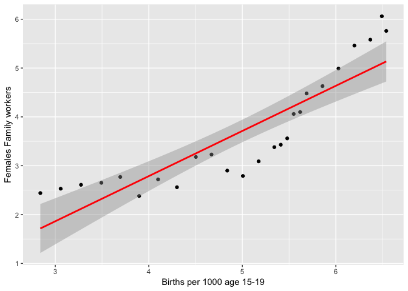

```r
ggplot(laborSwi, aes(x=n.x,y=n.y)) +
  geom_point() +
  stat_smooth(method = "lm", col = "red") +
  labs(x="Births per 1000 age 15-19",y="Females Family workers")
```

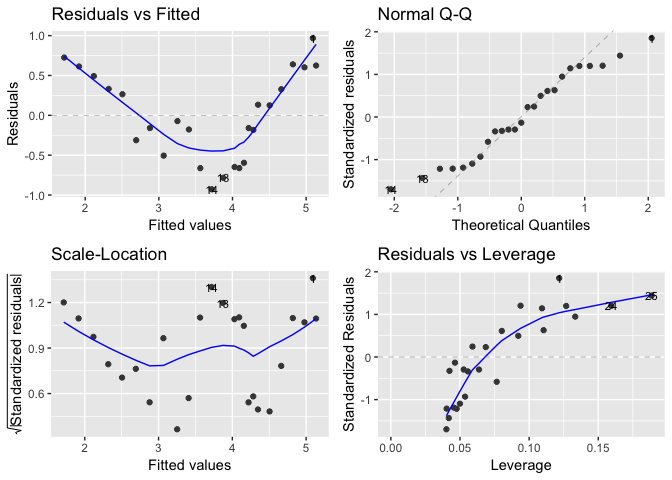

```r
autoplot(lm(n.y ~ n.x, data = laborSwi), label.size = 3)
```

26. Perform regression analysis for the gendered world indicators we considered above

```r
fertility_employment_Swi <- summary(lm(fertility_Swi$n~ male_family_workers_Swi$n))
fertility_employment_Swi
```

```
##
## Call:
## lm(formula = fertility_Swi$n ~ male_family_workers_Swi$n)
##
## Residuals:
##     Min      1Q  Median      3Q     Max
## -1.7340 -0.9537  0.1553  0.5637  2.0509
##
## Coefficients:
##                           Estimate Std. Error t value Pr(>|t|)
## (Intercept)                  1.224      2.008   0.610   0.5481
## male_family_workers_Swi$n    2.267      1.219   1.859   0.0758 .
## ---
## Signif. codes:  0 '***' 0.001 '**' 0.01 '*' 0.05 '.' 0.1 ' ' 1
##
## Residual standard error: 1.057 on 23 degrees of freedom
## Multiple R-squared:  0.1307, Adjusted R-squared:  0.09288
## F-statistic: 3.457 on 1 and 23 DF,  p-value: 0.07581
```

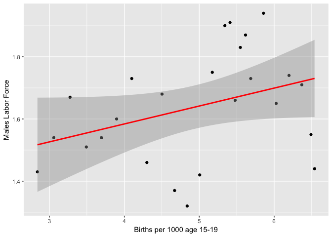

```r
ggplot(laborSwim, aes(x=n.x,y=n.y)) +
  geom_point() +
  stat_smooth(method = "lm", col = "red") +
  labs(x="Births per 1000 age 15-19",y="Males Labor Force")
```

**Health**

27. Perform regression analysis for the gendered world indicators we considered above

```r
fertility_health_Swi <- summary(lm(fertility_Swi$n ~ survival_65_female_Swi $n+ survival_65_male_Swi$n))
fertility_health_Swi
```

```
##
## Call:
## lm(formula = fertility_Swi$n ~ survival_65_female_Swi$n + survival_65_male_Swi$n)
##
## Residuals:
##     Min      1Q  Median      3Q     Max
## -6.4670 -0.7952 -0.2550  0.4503  4.0306
##
## Coefficients:
##                          Estimate Std. Error t value Pr(>|t|)
## (Intercept)              221.3466    17.3825  12.734  < 2e-16 ***
## survival_65_female_Swi$n  -2.9753     0.3780  -7.872 1.79e-10 ***
## survival_65_male_Swi$n     0.6687     0.2116   3.161   0.0026 **
## ---
## Signif. codes:  0 '***' 0.001 '**' 0.01 '*' 0.05 '.' 0.1 ' ' 1
##
## Residual standard error: 1.867 on 53 degrees of freedom
## Multiple R-squared:  0.9193, Adjusted R-squared:  0.9163
## F-statistic:   302 on 2 and 53 DF,  p-value: < 2.2e-16
```

Health is also correlated with adolescent pregnancy. Let’s dive deeper to find out how by looking at just one of these variables.

```r
fertility_health_Swi <- summary(lm(fertility_Swi$n~ survival_65_female_Swi $n ))
fertility_health_Swi
```

```
##
## Call:
## lm(formula = fertility_Swi$n ~ survival_65_female_Swi$n)
##
## Residuals:
##     Min      1Q  Median      3Q     Max
## -4.7905 -1.6367 -0.0799  1.3348  3.8579
##
## Coefficients:
##                           Estimate Std. Error t value Pr(>|t|)
## (Intercept)              170.49501    7.11300   23.97   <2e-16 ***
## survival_65_female_Swi$n  -1.80365    0.07993  -22.57   <2e-16 ***
## ---
## Signif. codes:  0 '***' 0.001 '**' 0.01 '*' 0.05 '.' 0.1 ' ' 1
##
## Residual standard error: 2.017 on 54 degrees of freedom
## Multiple R-squared:  0.9041, Adjusted R-squared:  0.9023
## F-statistic: 509.2 on 1 and 54 DF,  p-value: < 2.2e-16
```

```r
fertility_health_Swi <- summary(lm(fertility_Swi$n~ survival_65_male_Swi$n ))
fertility_health_Swi
```

```
##
## Call:
## lm(formula = fertility_Swi$n ~ survival_65_male_Swi$n)
##
## Residuals:
##     Min      1Q  Median      3Q     Max
## -4.1349 -2.5323  0.2333  2.0977  4.7194
##
## Coefficients:
##                        Estimate Std. Error t value Pr(>|t|)
## (Intercept)            87.02313    4.83440   18.00   <2e-16 ***
## survival_65_male_Swi$n -0.96432    0.06044  -15.96   <2e-16 ***
## ---
## Signif. codes:  0 '***' 0.001 '**' 0.01 '*' 0.05 '.' 0.1 ' ' 1
##
## Residual standard error: 2.725 on 54 degrees of freedom
## Multiple R-squared:  0.825,  Adjusted R-squared:  0.8218
## F-statistic: 254.6 on 1 and 54 DF,  p-value: < 2.2e-16
```

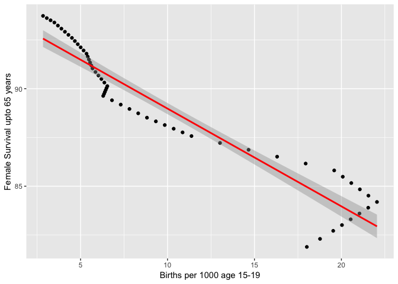

```r
ggplot(healthSwim, aes(x=n.x,y=n.y)) +
  geom_point() +
  stat_smooth(method = "lm", col = "red") +
  labs(x="Births per 1000 age 15-19",y="Female Survival upto 65 years")
```

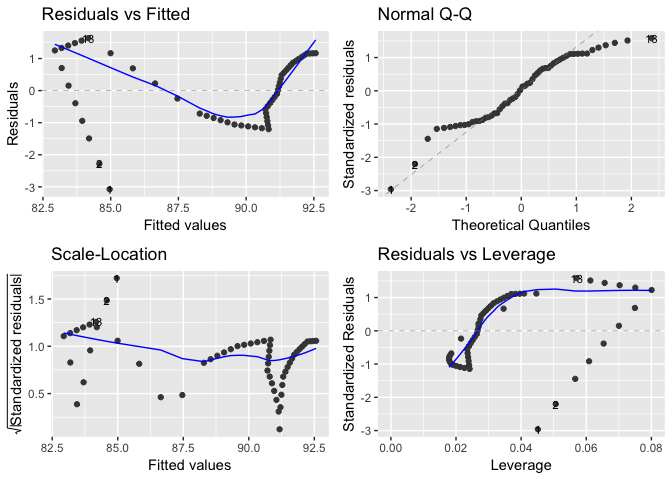

```r
autoplot(lm(n.y ~ n.x, data = healthSwim), label.size = 3)
```

### Inference

Let’s conduct hypothesis tests for the three countries we analyzed(Philippines, United States, Switzerland) taking the adolescent fertility rates as response variable and various world indicators as exploratory variable.

#### Philippines

```r
Philippines <- tidy_gendered_world_indicators %>%
  filter(Country == "Philippines")
#getting names of all potential indicators
indicators <- unique(Philippines$Indicator)
```

H0 = The mean of all the world indicators that effect the adolescent fertility rates are equal throughout from 1960 to 2015.

H1 = The mean of all the world indicators that effect the adolescent fertility rates are not equal throughout from 1960 to 2015.

```r
inference(data = Philippines$n, group = Philippines$year, est = "mean", type = "ht",  alternative = "greater", method = "theoretical")
```

```
## Response variable: numerical, Explanatory variable: categorical
## ANOVA
##
## Summary statistics:
## n_1960 = 8, mean_1960 = 108.5844, sd_1960 = 111.4037
## n_1961 = 8, mean_1961 = 108.0628, sd_1961 = 110.1926
## n_1962 = 8, mean_1962 = 107.5395, sd_1962 = 108.9841
## n_1963 = 8, mean_1963 = 107.1252, sd_1963 = 108.1576
## n_1964 = 8, mean_1964 = 106.7091, sd_1964 = 107.338
## n_1965 = 8, mean_1965 = 106.2924, sd_1965 = 106.5252
## n_1966 = 8, mean_1966 = 105.8756, sd_1966 = 105.7186
## n_1967 = 8, mean_1967 = 105.4586, sd_1967 = 104.9189
## n_1968 = 9, mean_1968 = 95.086, sd_1968 = 101.9698
## n_1969 = 8, mean_1969 = 104.6324, sd_1969 = 103.539
## n_1970 = 20, mean_1970 = 55.6774, sd_1970 = 75.1176
## n_1971 = 18, mean_1971 = 63.7313, sd_1971 = 77.342
## n_1972 = 16, mean_1972 = 64.7478, sd_1972 = 81.3583
## n_1973 = 17, mean_1973 = 62.2873, sd_1973 = 78.8748
## n_1974 = 14, mean_1974 = 72.8536, sd_1974 = 82.7464
## n_1975 = 23, mean_1975 = 55.9384, sd_1975 = 67.439
## n_1976 = 18, mean_1976 = 71.4045, sd_1976 = 74.7944
## n_1977 = 14, mean_1977 = 72.0719, sd_1977 = 81.1674
## n_1978 = 15, mean_1978 = 69.5403, sd_1978 = 78.2439
## n_1979 = 11, mean_1979 = 77.5875, sd_1979 = 90.7315
## n_1980 = 27, mean_1980 = 53.8608, sd_1980 = 61.4566
## n_1981 = 36, mean_1981 = 14545.68, sd_1981 = 60633.62
## n_1982 = 35, mean_1982 = 15220.01, sd_1982 = 63603.39
## n_1983 = 39, mean_1983 = 17227.48, sd_1983 = 75553.44
## n_1984 = 39, mean_1984 = 19071.7, sd_1984 = 85420.05
## n_1985 = 36, mean_1985 = 66.3896, sd_1985 = 57.0808
## n_1986 = 39, mean_1986 = 13621.17, sd_1986 = 59119.92
## n_1987 = 38, mean_1987 = 13745.63, sd_1987 = 59205.47
## n_1988 = 37, mean_1988 = 9573.564, sd_1988 = 41068.73
## n_1989 = 34, mean_1989 = 6663.447, sd_1989 = 27948.37
## n_1990 = 46, mean_1990 = 3219.737, sd_1990 = 17164.89
## n_1991 = 38, mean_1991 = 55.3709, sd_1991 = 57.1911
## n_1992 = 43, mean_1992 = 55.8417, sd_1992 = 56.6114
## n_1993 = 47, mean_1993 = 65.0502, sd_1993 = 86.7019
## n_1994 = 38, mean_1994 = 55.1517, sd_1994 = 57.3727
## n_1995 = 44, mean_1995 = 56.0172, sd_1995 = 56.0533
## n_1996 = 42, mean_1996 = 52.562, sd_1996 = 55.0959
## n_1997 = 43, mean_1997 = 60.3861, sd_1997 = 59.3708
## n_1998 = 79, mean_1998 = 11771.57, sd_1998 = 74233.35
## n_1999 = 76, mean_1999 = 16742.85, sd_1999 = 102331.3
## n_2000 = 66, mean_2000 = 48.9957, sd_2000 = 46.9671
## n_2001 = 94, mean_2001 = 13000.33, sd_2001 = 88738.48
## n_2002 = 81, mean_2002 = 14622.53, sd_2002 = 93106.14
## n_2003 = 102, mean_2003 = 11416, sd_2003 = 81335.37
## n_2004 = 93, mean_2004 = 13459.51, sd_2004 = 91623.83
## n_2005 = 83, mean_2005 = 16420.56, sd_2005 = 105591.6
## n_2006 = 82, mean_2006 = 19309.89, sd_2006 = 123329.3
## n_2007 = 77, mean_2007 = 20140.07, sd_2007 = 124747.1
## n_2008 = 109, mean_2008 = 12695.6, sd_2008 = 94150.04
## n_2009 = 78, mean_2009 = 14138.2, sd_2009 = 89509.39
## n_2010 = 67, mean_2010 = 44.7021, sd_2010 = 47.8824
## n_2011 = 68, mean_2011 = 44.784, sd_2011 = 53.2174
## n_2012 = 46, mean_2012 = 46.8839, sd_2012 = 55.4703
## n_2013 = 117, mean_2013 = 3485.665, sd_2013 = 31277.99
## n_2014 = 47, mean_2014 = 45.5432, sd_2014 = 56.4885
## n_2015 = 51, mean_2015 = 42.4092, sd_2015 = 56.58
```

```
## H_0: All means are equal.
## H_A: At least one mean is different.
## Analysis of Variance Table
##
## Response: data
##             Df     Sum Sq    Mean Sq F value Pr(>F)
## group       55 1.2730e+11 2314551710  0.5227 0.9986
## Residuals 2308 1.0221e+13 4428476709
```

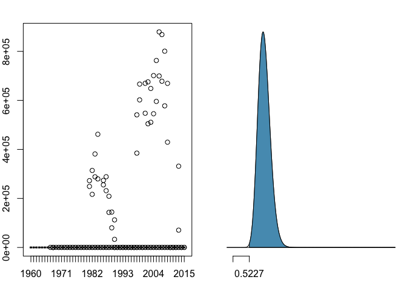

As we can see, p-value is greater than 0.05.

1. Therefore, we fail to reject the null hypothesis and conclude that **The mean of all the world indicators that effect the adolescent fertility rates are almost equal throughout from 1960 to 2015.** . It does not necessarily vary for each of the world indicators.
2. And also, as we saw inference results for Switzerland ,we reject the null hypothesis, which further proves that adolescent fertility rates of these countries is much improved or affected by world indicators. Their adolescent fertility rates are also impacted by the scocio-economic factors which overall results in constant decreasing feritlity rates in Switzerland.

#### United States

```r
UnitedStates <- tidy_gendered_world_indicators %>%
  filter(Country == "United States")
#getting names of all potential indicators
indicators <- unique(UnitedStates$Indicator)
```

```r
US <- subset(UnitedStates)
```

H0 = The mean of all the world indicators that effect the adolescent fertility rates are equal throughout from 1960 to 2015.

H1 = The mean of all the world indicators that effect the adolescent fertility rates are not equal throughout from 1960 to 2015.

```r
inference(data = US$n, group = US$year, est = "mean", type = "ht",  alternative = "greater", method = "theoretical")
```

```
## Response variable: numerical, Explanatory variable: categorical
## ANOVA
##
## Summary statistics:
## n_1960 = 10, mean_1960 = 74.9233, sd_1960 = 68.892
## n_1961 = 10, mean_1961 = 73.6712, sd_1961 = 66.8921
## n_1962 = 10, mean_1962 = 73.8539, sd_1962 = 67.9554
## n_1963 = 10, mean_1963 = 74.0197, sd_1963 = 69.143
## n_1964 = 10, mean_1964 = 73.4898, sd_1964 = 68.7855
## n_1965 = 10, mean_1965 = 73.1848, sd_1965 = 69.0325
## n_1966 = 10, mean_1966 = 73.175, sd_1966 = 70.1394
## n_1967 = 10, mean_1967 = 72.6235, sd_1967 = 69.6596
## n_1968 = 10, mean_1968 = 73.344, sd_1968 = 71.6037
## n_1969 = 10, mean_1969 = 72.9705, sd_1969 = 71.1177
## n_1970 = 20, mean_1970 = 66.9247, sd_1970 = 53.0924
## n_1971 = 13, mean_1971 = 62.6075, sd_1971 = 63.4069
## n_1972 = 18, mean_1972 = 58.4416, sd_1972 = 56.9351
## n_1973 = 14, mean_1973 = 62.7024, sd_1973 = 59.9224
## n_1974 = 13, mean_1974 = 61.1609, sd_1974 = 59.9746
## n_1975 = 17, mean_1975 = 55.6956, sd_1975 = 52.4199
## n_1976 = 22, mean_1976 = 48.8161, sd_1976 = 51.2244
## n_1977 = 21, mean_1977 = 47.4507, sd_1977 = 51.5511
## n_1978 = 26, mean_1978 = 48.5422, sd_1978 = 47.7032
## n_1979 = 24, mean_1979 = 44.9336, sd_1979 = 47.1171
## n_1980 = 33, mean_1980 = 57.0316, sd_1980 = 44.7322
## n_1981 = 36, mean_1981 = 47.6418, sd_1981 = 43.1123
## n_1982 = 34, mean_1982 = 49.767, sd_1982 = 43.7865
## n_1983 = 37, mean_1983 = 49.0464, sd_1983 = 42.25
## n_1984 = 35, mean_1984 = 48.7641, sd_1984 = 43.3831
## n_1985 = 35, mean_1985 = 48.6942, sd_1985 = 43.4296
## n_1986 = 39, mean_1986 = 35005.85, sd_1986 = 155139.9
## n_1987 = 39, mean_1987 = 26492.18, sd_1987 = 118847.3
## n_1988 = 28, mean_1988 = 49.3122, sd_1988 = 42.7578
## n_1989 = 28, mean_1989 = 50.2716, sd_1989 = 43.4351
## n_1990 = 50, mean_1990 = 8395.971, sd_1990 = 43077.6
## n_1991 = 57, mean_1991 = 7644.347, sd_1991 = 40203.75
## n_1992 = 38, mean_1992 = 154.0493, sd_1992 = 675.2128
## n_1993 = 55, mean_1993 = 16170.78, sd_1993 = 83374.73
## n_1994 = 58, mean_1994 = 17063.22, sd_1994 = 90962.72
## n_1995 = 58, mean_1995 = 11821.67, sd_1995 = 62600.74
## n_1996 = 58, mean_1996 = 14234.4, sd_1996 = 75799.54
## n_1997 = 39, mean_1997 = 159.9535, sd_1997 = 730.6688
## n_1998 = 58, mean_1998 = 129.3176, sd_1998 = 611.9019
## n_1999 = 58, mean_1999 = 10448.19, sd_1999 = 55579.76
## n_2000 = 67, mean_2000 = 8778.672, sd_2000 = 49890.47
## n_2001 = 66, mean_2001 = 10115.85, sd_2001 = 59410.61
## n_2002 = 71, mean_2002 = 14015.82, sd_2002 = 84247.31
## n_2003 = 66, mean_2003 = 16823.83, sd_2003 = 96567.31
## n_2004 = 83, mean_2004 = 16564.21, sd_2004 = 106582.2
## n_2005 = 87, mean_2005 = 13287.56, sd_2005 = 87797.99
## n_2006 = 81, mean_2006 = 11175.01, sd_2006 = 72886.98
## n_2007 = 67, mean_2007 = 10162.95, sd_2007 = 59725.54
## n_2008 = 79, mean_2008 = 7699.791, sd_2008 = 48401.22
## n_2009 = 83, mean_2009 = 11582.48, sd_2009 = 76554.21
## n_2010 = 83, mean_2010 = 15301.84, sd_2010 = 97703.38
## n_2011 = 83, mean_2011 = 17941.72, sd_2011 = 115370.3
## n_2012 = 82, mean_2012 = 17690.17, sd_2012 = 111954.2
## n_2013 = 95, mean_2013 = 16050.27, sd_2013 = 109429.7
## n_2014 = 90, mean_2014 = 16436.14, sd_2014 = 109396.4
## n_2015 = 83, mean_2015 = 16621.01, sd_2015 = 106133.9
```

```
## H_0: All means are equal.
## H_A: At least one mean is different.
## Analysis of Variance Table
##
## Response: data
##             Df     Sum Sq    Mean Sq F value Pr(>F)
## group       55 1.4222e+11 2585758335    0.45 0.9998
## Residuals 2371 1.3626e+13 5746733270
```

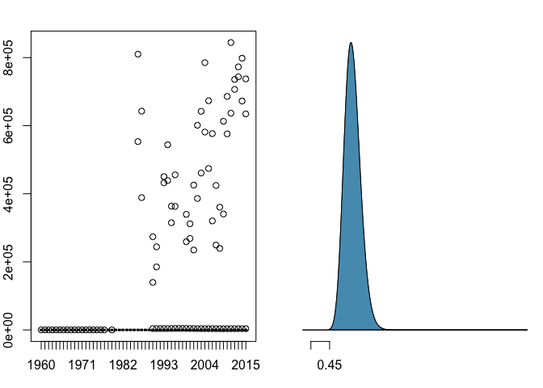

As we can see, p-value is greater than 0.05.

Therefore, we fail to reject the null hypothesis and conclude that **The mean of all the world indicators that effect the adolescent fertility rates are almost equal throughout from 1960 to 2015.** . It does not necessarily vary for each of the world indicators.

#### Switzerland

```r
Switzerland <- tidy_gendered_world_indicators %>%
  filter(Country == "Switzerland")
#getting names of all potential indicators
indicators <- unique(Switzerland$Indicator)
```

```r
SWI <- subset(Switzerland)
```

H0 = The mean of all the world indicators that effect the adolescent fertility rates are equal throughout from 1960 to 2015.

H1 = The mean of all the world indicators that effect the adolescent fertility rates are not equal throughout from 1960 to 2015.

```r
inference(data = SWI$n, group = SWI$year, est = "mean", type = "ht",  alternative = "greater", method = "theoretical")
```

```
## Response variable: numerical, Explanatory variable: categorical
## ANOVA
##
## Summary statistics:
## n_1960 = 8, mean_1960 = 74.0695, sd_1960 = 53.3394
## n_1961 = 8, mean_1961 = 74.7377, sd_1961 = 53.8973
## n_1962 = 8, mean_1962 = 75.1682, sd_1962 = 54.7209
## n_1963 = 8, mean_1963 = 75.2169, sd_1963 = 54.8187
## n_1964 = 8, mean_1964 = 73.8852, sd_1964 = 51.9338
## n_1965 = 8, mean_1965 = 72.8164, sd_1965 = 49.5074
## n_1966 = 8, mean_1966 = 73.2924, sd_1966 = 50.2585
## n_1967 = 8, mean_1967 = 72.3472, sd_1967 = 48.7398
## n_1968 = 8, mean_1968 = 73.083, sd_1968 = 49.4413
## n_1969 = 8, mean_1969 = 73.0788, sd_1969 = 49.6322
## n_1970 = 11, mean_1970 = 58.5483, sd_1970 = 47.5673
## n_1971 = 14, mean_1971 = 55.5627, sd_1971 = 42.9075
## n_1972 = 14, mean_1972 = 55.1392, sd_1972 = 42.3431
## n_1973 = 18, mean_1973 = 55.4277, sd_1973 = 40.4585
## n_1974 = 18, mean_1974 = 55.0869, sd_1974 = 40.2221
## n_1975 = 18, mean_1975 = 55.1648, sd_1975 = 40.806
## n_1976 = 18, mean_1976 = 54.6655, sd_1976 = 40.2853
## n_1977 = 36, mean_1977 = 4152.888, sd_1977 = 17183.49
## n_1978 = 42, mean_1978 = 3443.499, sd_1978 = 15386.54
## n_1979 = 41, mean_1979 = 50.7345, sd_1979 = 35.9714
## n_1980 = 48, mean_1980 = 45.2039, sd_1980 = 34.9836
## n_1981 = 42, mean_1981 = 3030.495, sd_1981 = 13505.95
## n_1982 = 42, mean_1982 = 2925.967, sd_1982 = 13030.33
## n_1983 = 42, mean_1983 = 2865.101, sd_1983 = 12760.53
## n_1984 = 42, mean_1984 = 2829.138, sd_1984 = 12600.48
## n_1985 = 42, mean_1985 = 2748.102, sd_1985 = 12229.42
## n_1986 = 42, mean_1986 = 2629.059, sd_1986 = 11687.4
## n_1987 = 38, mean_1987 = 2695.122, sd_1987 = 11394.26
## n_1988 = 38, mean_1988 = 2442.271, sd_1988 = 10303.96
## n_1989 = 38, mean_1989 = 2181.752, sd_1989 = 9176.202
## n_1990 = 46, mean_1990 = 1807.73, sd_1990 = 7623.057
## n_1991 = 63, mean_1991 = 1283.637, sd_1991 = 6291.698
## n_1992 = 63, mean_1992 = 1305.164, sd_1992 = 6403.869
## n_1993 = 63, mean_1993 = 1387.017, sd_1993 = 6866.976
## n_1994 = 64, mean_1994 = 1453.822, sd_1994 = 7310.543
## n_1995 = 58, mean_1995 = 1085.242, sd_1995 = 4948.182
## n_1996 = 63, mean_1996 = 879.531, sd_1996 = 4028.558
## n_1997 = 40, mean_1997 = 254.1827, sd_1997 = 1370.046
## n_1998 = 58, mean_1998 = 203.8342, sd_1998 = 1215.903
## n_1999 = 72, mean_1999 = 214.4468, sd_1999 = 1121.108
## n_2000 = 74, mean_2000 = 230.7851, sd_2000 = 1198.17
## n_2001 = 72, mean_2001 = 244.6979, sd_2001 = 1254.142
## n_2002 = 72, mean_2002 = 243.1294, sd_2002 = 1244.675
## n_2003 = 74, mean_2003 = 247.6169, sd_2003 = 1307.291
## n_2004 = 70, mean_2004 = 287.1735, sd_2004 = 1396.932
## n_2005 = 74, mean_2005 = 324.4215, sd_2005 = 1460.704
## n_2006 = 73, mean_2006 = 359.6075, sd_2006 = 1592.645
## n_2007 = 72, mean_2007 = 362.9453, sd_2007 = 1637.897
## n_2008 = 72, mean_2008 = 311.784, sd_2008 = 1507.546
## n_2009 = 92, mean_2009 = 234.166, sd_2009 = 1328.806
## n_2010 = 86, mean_2010 = 235.2841, sd_2010 = 1293.641
## n_2011 = 89, mean_2011 = 218.297, sd_2011 = 1261.809
## n_2012 = 88, mean_2012 = 230.0233, sd_2012 = 1325.679
## n_2013 = 80, mean_2013 = 219.74, sd_2013 = 1377.42
## n_2014 = 92, mean_2014 = 202.3721, sd_2014 = 1293.99
## n_2015 = 95, mean_2015 = 191.8156, sd_2015 = 1274.956
```

```
## H_0: All means are equal.
## H_A: At least one mean is different.
## Analysis of Variance Table
##
## Response: data
##             Df     Sum Sq  Mean Sq F value  Pr(>F)
## group       55 2.7777e+09 50503364  1.4194 0.02366
## Residuals 2533 9.0125e+10 35580526
##
## Pairwise tests: t tests with pooled SD
##        1960   1961   1962   1963   1964   1965   1966   1967   1968   1969
## 1961 0.9998     NA     NA     NA     NA     NA     NA     NA     NA     NA
## 1962 0.9997 0.9999     NA     NA     NA     NA     NA     NA     NA     NA
## 1963 0.9997 0.9999 1.0000     NA     NA     NA     NA     NA     NA     NA
## 1964 1.0000 0.9998 0.9997 0.9996     NA     NA     NA     NA     NA     NA
```

[output cut: 331 more lines]

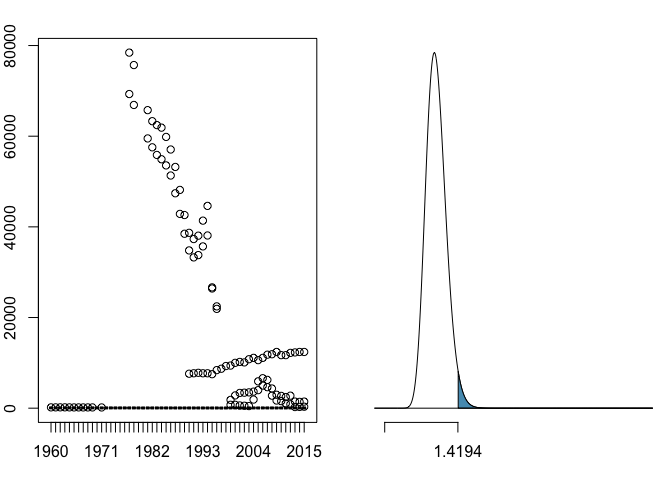

As we can see, p-value is less than 0.05.

Therefore, we reject the null hypothesis and conclude that **The mean of all the world indicators that effect the adolescent fertility rates are not equal throughout from 1960 to 2015.** . It varies for each of the world indicators.

### Conclusion

It is often citied that the decrease in pregnancy overall is due to things like access to contraception and sex-education programs. In this study, various World Bank indicators were regressed against adolescent preganancy rates within Philippines, United States, and Switzerland.

**Philippines**

In the Philippines, rates are increasing (one of the few countries) despite lower risks of maternal death, and increasing survival rates (alluding to better healthcare overall). The country should allow for the use of contraceptives and sex-education programs. There is something to be said that the country has good education rates and increased teenage pregnancies. Their other metrics are ok – there is something holding them back, and that’s a flawed outlook on pregnancy.

**United States**

**Switzerland**

Switzerland, on the other hand is attempting to improve, and in doing so more rapidly than their metrics would allude to. There is likely some form out outside influence going on. Of the 3 countries with complete estimates of young adolescent pregnancy rates, the lowest was in Switzerland.

Now let’s see the factors which these countries adopts which leads to different levels of adolescent fertility rates and answer the research questions we formulated at the beginning of this project.

**1) Which countries have the most significant increasing/decreasing adolescent fertility rates.**

Swizerland’s adolescent fertility rates are most significantly decreasing out of all the countries.

**2) Determine potential reasons for what in particular makes countries with decreasing or consistent fertility rates different from countries with higher or increasing fertility rates?**

Factors leading to increasing pregnency rates:

1. Studies have more frequently examined the relationship among social, economic, and cultural factors and differences in teen pregnancy rates within countries. In the United Kingdom and the United States, for example, teen pregnancy rates are higher in the most socioeconomically disadvantaged groups.
2. In the United States, the pregnancy rate is 100 among black teenagers and 38 among white teens (a rate that is still high for a developed country),9 although this differential has decreased with time .
3. Qualitative research in the United Kingdom points to poor material circumstances, unhappiness at home or at school, and low expectations for the future as factors associated with high teen pregnancy rates.

Factors leading to decreasing pregnency rates:

1. At the other end of the spectrum, the very low teen pregnancy rate in Switzerland exists in the context of long-established sex education programs, widespread expectation that sexually active teens will use contraception, free family planning services and low-cost emergency contraception.
2. But even in Switzerland, statistics indicate that teen pregnancy rates vary with levels of education and cultural background of adolescent girls.

Additional research would help us better understand circumstances that can lead to teen pregnancies and how these circumstances can be influenced. Examination of the factors that influence whether an adolescent who gets pregnant will seek an abortion or have a child can also inform how adolescents can be supported in the face of a pregnancy.

Moreover, further research to help disentangle the factors that are causally associated with unplanned teen pregnancies from the factors that are simply correlated with such pregnancies can inform interventions aimed at helping adolescent girls avoid unintended pregnancy and instead take advantage of other opportunities before them.

### References

1. [World Health Organization on adolescent pregnency](https://www.who.int/news-room/fact-sheets/detail/adolescent-pregnancy)
2. [Socio Economic Factors in teenage pregnency rates](https://www.guttmacher.org/journals/psrh/2001/11/differences-teenage-pregnancy-rates-among-five-developed-countries-roles)
3. [Adolescent Pregnancy, Birth, and Abortion Rates Across Countries: Levels and Recent Trends](https://www.ncbi.nlm.nih.gov/pmc/articles/PMC4852976/)